# Tölvuverkefni 2

Enar Kornelius Leferink (ekl4@hi.is) og Sverrir Arnórsson (sva19@hi.is)

15/02/2019

## 1

### a)

Gögn lesin inn, Enar Kornelius notaði sinn afmælisdag til að búa til seed og þannig valið handahófskennt hverfi úr gefnum lista af hverfum. Bara íbúðareignir valdar.

```r
es <- read.table("https://notendur.hi.is/~ahj/husnaedi.txt", sep=";", header=T)
set.seed(2605)
hverfi <- sample(c(80,130,160,200),1)
print(sample(c(80,130,160,200),1))
```

```
## [1] 130
```

Þannig okkar hverfi er Hlíðar. Íbúðareignir valdar úr Hlíðunum.

```r
es <- filter(es, matssvaedi%in%hverfi)
es <- filter(es, teg_eign=="Íbúðareign")
```

### b)

Stuðlarit af verði íbúðanna. Meðalverð er 24621.89 og dreifni er 28211443.

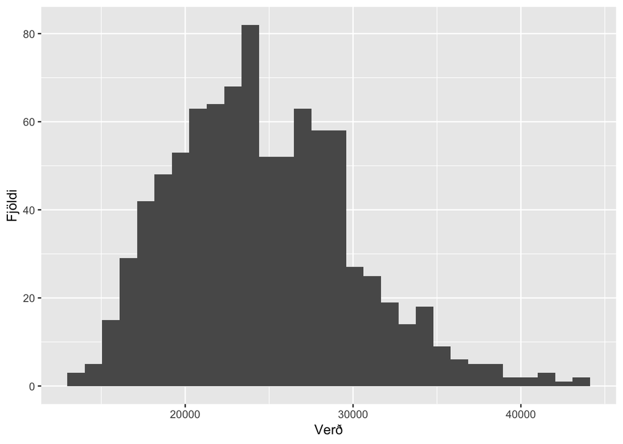

```r
ggplot(data=es ,aes(nuvirdi)) + geom_histogram() + xlab("Verð")+ylab("Fjöldi")
```

### c)

Úrtak af mismunandi stærðum tekið 10000 sinnum og vistað í viðeigandi vigrum. Replicate aðferðin notuð.

```r
staerd1 <- replicate(10000, mean(sample(es$nuvirdi,10)))
staerd2 <- replicate(10000, mean(sample(es$nuvirdi,30)))
staerd3 <- replicate(10000, mean(sample(es$nuvirdi,100)))
staerd4 <- replicate(10000, mean(sample(es$nuvirdi,200)))
```

### d)

Stuðlarit teiknað fyrir mismunandi stærðir. Það var gert með því að búa til gagnatöflu á hentugu sniði. Fyrst var búin til gagnatafla með víðu sniði sem var svo breytt yfir í gagnatöflu með löngu sniði. Við flokkuðum eftir úrtaksstærð með aðferðini facet_wrap.

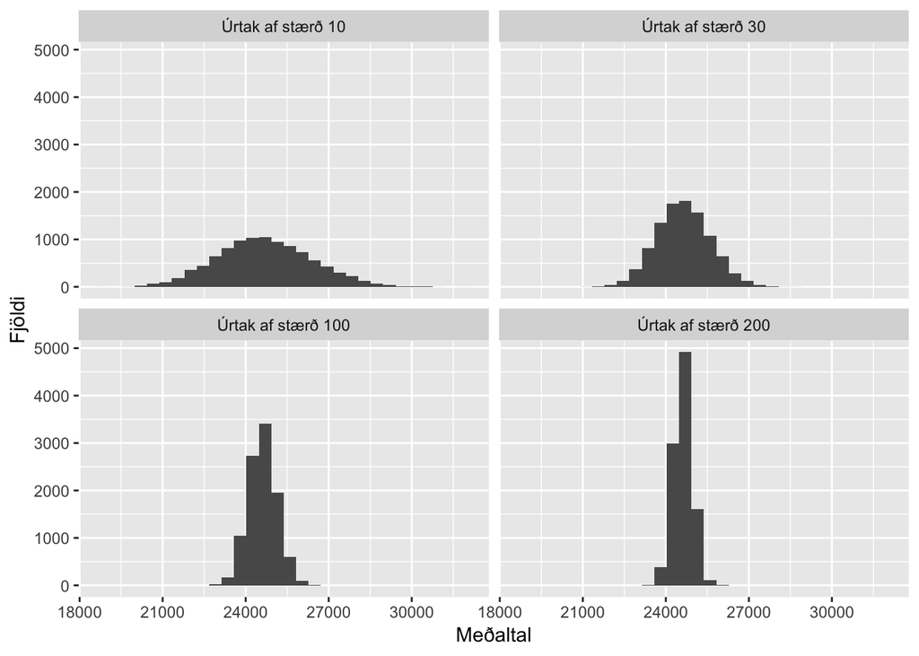

```r
hmr.es <- data.frame(staerd1, staerd2, staerd3, staerd4)
hmr.es.long <-gather(hmr.es, staerd, medaltal)
levels <- c(staerd1, staerd2, staerd3, staerd4)
hmr.es.long$staerd <- as.factor(hmr.es.long$staerd)
levels <- c(staerd1, staerd2, staerd3, staerd4)
labels <- c("Úrtak af stærð 10", "Úrtak af stærð 30", "Úrtak af stærð 100", "Úrtak af stærð 200")
hmr.es.long$staerd <-factor(hmr.es.long$staerd, levels=levels(hmr.es.long$staerd), labels=labels)



ggplot(hmr.es.long, aes(medaltal)) + geom_histogram() + facet_wrap(vars(staerd)) + xlab("Meðaltal") + ylab("Fjöldi")
```

### e)

Sama stuðlarit og í d) lið teiknað nema í þetta sinn var skalinn frjáls fyrir hvert graf fyrir sig.

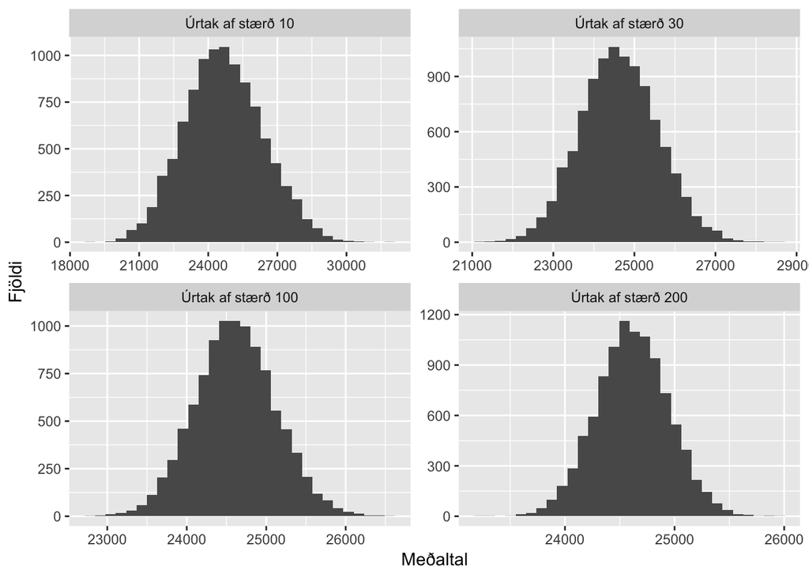

```r
ggplot(hmr.es.long, aes(medaltal)) + geom_histogram() + facet_wrap(vars(staerd), scales = "free") + xlab("Meðaltal") + ylab("Fjöldi")
```

### f)

Meðaltal og dreifni fyrir hverja úrtaksstærð reiknað og sett upp í töflu ásamt fjölda.

```r
tafla <- hmr.es.long %>% group_by(Úrtaksstærð = staerd)  %>% summarize(Fjöldi = n(), Meðaltal = mean(medaltal), Dreifni = var(medaltal))
knitr::kable(tafla)
```

| Úrtaksstærð | Fjöldi | Meðaltal | Dreifni |
| --- | --- | --- | --- |
| Úrtak af stærð 10 | 10000 | 24680.86 | 2881753.5 |
| Úrtak af stærð 30 | 10000 | 24630.34 | 913692.5 |
| Úrtak af stærð 100 | 10000 | 24613.58 | 254409.7 |
| Úrtak af stærð 200 | 10000 | 24615.24 | 108481.6 |

### g)

Það sem að sést í liðum d), e) og f) er að eftir því sem að úrtaksstærðin $n$ er aukin þá minnkar dreifni. Jafnframt er meðaltal um það bil það sama fyrir allar úrtaksstærðirnar. Það er í samræmi við höfuðmarkgildisregluna. Hún segir að dreifnin á $var(\bar{X})=\frac{\sigma^2}{n}$. Það kemur heim og saman við niðurstöður okkar. Fræðileg dreifni var 28211443 sem fæst frá dreifninni fyrir allt þýðið. Fyrir mismunandi úrtaksstærðir okkar þá fengust gildi á dreifni sem samsvara áðurnefndri formúlu fyrir dreifni. Skoðum aðeins það sem við fengum. Fyrir $n=10$ ætti dreifnin að vera $var(X)=\frac{\sigma^2}{n}=\frac{28211443}{10}=2821144$, sem passar nokkuð vel við fengið gildi á dreifni í töflunni í lið f). Sama fæst fyrir hinar úrtaksstærðirnar. Höfuðmarkgildisreglan segir enn fremur að meðalgildið sé jafnt meðalgildi þýðisins, eða $E(\bar{X})=\mu$, sem er nokkurn veginn það sem við fáum í töflunni fyrir hverja úrtaksstærð.